# Demo: Using Additional CAS Actions

### 1. Import Packages and Connect to the CAS Server

Visit the documentation for the SWAT [(SAS Scripting Wrapper for Analytics Transfer)](https://sassoftware.github.io/python-swat/index.html) package.

```python
## Import packages
import swat
import pandas as pd
import matplotlib.pyplot as plt
plt.style.use('seaborn')
import seaborn as sns

## Set options
pd.set_option('display.max_columns', None)

## Connect to CAS
conn = swat.CAS('server.demo.sas.com', 30571, 'student', 'Metadata0', name = 'py04d02')

## Function to load the loans_raw.sashdat file into memory if necessary
def loadLoans():
    conn.loadTable(path = 'loans_raw.sashdat', caslib = 'PIVY',
                   casOut = {'name' : 'loans_raw',
                            'caslib' : 'casuser',
                            'promote' : True})
```

### 2. Explore Available CAS Tables

a. Use the tableInfo action to view all available in-memory tables in the **Casuser** caslib. If the **LOANS_RAW** CAS table is not available, uncomment the loadLoans function and execute the cell.

```python
#loadLoans()
conn.tableInfo(caslib = 'casuser')
```

**§ TableInfo**

|  | Name | Label | Rows | Columns | IndexedColumns | Encoding | CreateTimeFormatted | ModTimeFormatted | AccessTimeFormatted | JavaCharSet | CreateTime | ModTime | AccessTime | Global | Repeated | View | MultiPart | SourceName | SourceCaslib | Compressed | Creator | Modifier | SourceModTimeFormatted | SourceModTime |
| --- | --- | --- | --- | --- | --- | --- | --- | --- | --- | --- | --- | --- | --- | --- | --- | --- | --- | --- | --- | --- | --- | --- | --- | --- |
| 0 | CARS | 2004 Car Data | 428 | 15 | 0 | utf-8 | 2022-03-17T19:30:27+00:00 | 2022-03-17T19:30:27+00:00 | 2022-03-17T20:27:32+00:00 | UTF8 | 1.963165e+09 | 1.963165e+09 | 1.963168e+09 | 1 | 0 | 0 | 0 | cars.sas7bdat | PIVY | 0 | student |  | 2021-12-17T18:43:57+00:00 | 1.955386e+09 |
| 1 | LOANS_RAW |  | 16311047 | 20 | 0 | utf-8 | 2022-03-17T20:28:57+00:00 | 2022-03-17T20:28:57+00:00 | 2022-03-17T20:36:54+00:00 | UTF8 | 1.963168e+09 | 1.963168e+09 | 1.963169e+09 | 1 | 0 | 0 | 0 | loans_raw.sashdat | PIVY | 0 | student |  | 2021-12-17T18:40:14+00:00 | 1.955386e+09 |

elapsed 0.00281s · user 0.00214s · sys 3e-05s · mem 0.826MB

b. Reference the **LOANS_RAW** CAS table where **Category** equals *Mortgage*. Then preview the table.

```python
mTbl = conn.CASTable('loans_raw',
                     caslib = 'casuser',
                     where = "Category = 'Mortgage'")
mTbl.head()
```

Selected Rows from Table LOANS_RAW

|  | ID | AccNumber | Year | Month | Day | CurrentDate | SalaryGroup | Age | Salary | EmpLength | Category | Amount | InterestRate | LoanLength | LoanGrade | LoanStatus | LastPurchase | Cancelled | CancelledReason | Promotion |
| --- | --- | --- | --- | --- | --- | --- | --- | --- | --- | --- | --- | --- | --- | --- | --- | --- | --- | --- | --- | --- |
| 0 | I-00006307127350009978 | M9708726115059108-92217000 | 2016.0 | 3.0 | 15.0 | 31DEC2022 | Less than $50,000 | 30.0 | 9128.0 | 11.0 | Mortgage | 13642.37 | 5.00 | 30.0 | C | Current | NaT | 0.0 |  | 0.0 |
| 1 | I-00002584305626805872 | M7532880555372686-20868000 | 2019.0 | 11.0 | 8.0 | 31DEC2022 | $50,001 - $100,000 | 39.0 | 43267.0 | 16.0 | Mortgage | 108746.10 | 4.02 | 30.0 | C | Current | NaT | 0.0 |  | 0.0 |
| 2 | I-00008523092262912542 | M6207822721917183-40578000 | 2022.0 | 9.0 | 17.0 | 31DEC2022 | $250,001-$500,000 | 44.0 | 280609.0 | 9.0 | Mortgage | 734670.42 | 5.17 | 30.0 | D | Current | NaT | 0.0 |  | 0.0 |
| 3 | D-00003274282454513014 | M8984404872171582-30765000 | 2018.0 | 1.0 | 8.0 | 31DEC2022 | $100,001 - $250,000 | 39.0 | 138868.0 | 6.0 | Mortgage | 289033.31 | 4.33 | 30.0 | A | Current | NaT | 0.0 |  | 0.0 |
| 4 | E-00003731750759761782 | M8101555942557753-93571000 | 2015.0 | 6.0 | 12.0 | 31DEC2022 | $100,001 - $250,000 | 46.0 | 121081.0 | 9.0 | Mortgage | 235511.61 | 4.56 | 30.0 | C | Current | NaT | 0.0 |  | 0.0 |

### 3. Simple Action Set

a. You can use the [simple.correlation](https://go.documentation.sas.com/doc/en/pgmsascdc/v_018/casanpg/n11jidodvxk3tkn1sy8636iha1po.htm#p0jytlrw1nn19tn1782gu5c2cv43) action to generate a matrix of Pearson correlation coefficients for two or more input columns. By default, univariate descriptive statistics are also generated for the analysis variables. You can disable the univariate descriptive statistics if you do not need them.

```python
colNames = ['Age', 'EmpLength', 'Amount', 'InterestRate', 'LoanLength']
mTbl.correlation(inputs = colNames)

## Alternate version
#mTbl.vars = ['Age', 'EmpLength', 'Amount', 'InterestRate', 'LoanLength']
#mTbl.correlation()
```

**§ CorrSimple**

Summary Statistics in Correlation Analysis for LOANS_RAW

|  | Variable | N | Mean | Sum | StdDev | Minimum | Maximum |
| --- | --- | --- | --- | --- | --- | --- | --- |
| 0 | Age | 1243328.0 | 42.475812 | 5.281137e+07 | 12.121880 | 18.00 | 70.00 |
| 1 | EmpLength | 1238512.0 | 11.553853 | 1.430959e+07 | 4.439893 | 0.00 | 33.00 |
| 2 | Amount | 1243328.0 | 373073.617129 | 4.638529e+11 | 665842.055878 | 2227.42 | 10618599.32 |
| 3 | InterestRate | 1243328.0 | 4.144955 | 5.153538e+06 | 0.885174 | 1.70 | 9.04 |
| 4 | LoanLength | 1243328.0 | 26.446879 | 3.288214e+07 | 6.300917 | 10.00 | 30.00 |

**§ Correlation**

Pearson Correlation Coefficients for LOANS_RAW

|  | Variable | Age | EmpLength | Amount | InterestRate | LoanLength | Nobs1 | Nobs2 | Nobs3 | Nobs4 | Nobs5 |
| --- | --- | --- | --- | --- | --- | --- | --- | --- | --- | --- | --- |
| 0 | Age | 1.000000 | 0.000176 | 0.327069 | -0.048665 | -0.000313 | 1243328.0 | 1238512.0 | 1243328.0 | 1243328.0 | 1243328.0 |
| 1 | EmpLength | 0.000176 | 1.000000 | 0.001507 | 0.000597 | -0.000712 | 1238512.0 | 1238512.0 | 1238512.0 | 1238512.0 | 1238512.0 |
| 2 | Amount | 0.327069 | 0.001507 | 1.000000 | -0.109539 | -0.000368 | 1243328.0 | 1238512.0 | 1243328.0 | 1243328.0 | 1243328.0 |
| 3 | InterestRate | -0.048665 | 0.000597 | -0.109539 | 1.000000 | 0.000605 | 1243328.0 | 1238512.0 | 1243328.0 | 1243328.0 | 1243328.0 |
| 4 | LoanLength | -0.000313 | -0.000712 | -0.000368 | 0.000605 | 1.000000 | 1243328.0 | 1238512.0 | 1243328.0 | 1243328.0 | 1243328.0 |

elapsed 0.801s · user 4.98s · sys 1.91s · mem 3.4MB

b. The SWAT package also provides the Pandas corr method to return similar results.

```python
mTbl[colNames].corr()
```

Pearson Correlation Coefficients for LOANS_RAW

|  | Age | EmpLength | Amount | InterestRate | LoanLength |
| --- | --- | --- | --- | --- | --- |
| Age | 1.000000 | 0.000176 | 0.327069 | -0.048665 | -0.000313 |
| EmpLength | 0.000176 | 1.000000 | 0.001507 | 0.000597 | -0.000712 |
| Amount | 0.327069 | 0.001507 | 1.000000 | -0.109539 | -0.000368 |
| InterestRate | -0.048665 | 0.000597 | -0.109539 | 1.000000 | 0.000605 |
| LoanLength | -0.000313 | -0.000712 | -0.000368 | 0.000605 | 1.000000 |

c. Use the [simple.topk](https://go.documentation.sas.com/doc/en/pgmsascdc/v_018/casanpg/cas-simple-topk.htm) action to return the top-K and bottom-K distinct values of each column included in the list. In this example the top five and bottom five mortgage interest rates are returned. The inputs parameter specifies the **InterestRate** column, and the raw parameter specifies to use the raw values and avoid masking values with any SAS formats. The action returns two **SASDataFrames**. The first shows the top five and bottom five interest rates, and the second shows the number of unique values in the column.

```python
mTbl.topk(inputs = 'InterestRate',
          topk = 5,
          bottomk = 5,
          raw = True) # <-avoid masking by autoformatting values
```

**§ Topk**

Top and Bottom Distinct Values for LOANS_RAW

|  | Column | NumVar | Rank |
| --- | --- | --- | --- |
| 0 | InterestRate | 9.04 | 1 |
| 1 | InterestRate | 8.82 | 2 |
| 2 | InterestRate | 8.75 | 3 |
| 3 | InterestRate | 8.70 | 4 |
| 4 | InterestRate | 8.66 | 5 |
| 5 | InterestRate | 1.70 | 676 |
| 6 | InterestRate | 1.71 | 675 |
| 7 | InterestRate | 1.73 | 674 |
| 8 | InterestRate | 1.74 | 673 |
| 9 | InterestRate | 1.77 | 672 |

**§ TopkMisc**

Miscellaneous Information on Distinct Values for LOANS_RAW

|  | Column | N | TruncatedTopk | TruncatedBtmk | ScoreOther |
| --- | --- | --- | --- | --- | --- |
| 0 | InterestRate | 676 | 0 | 0 | NaN |

elapsed 0.281s · user 2.77s · sys 0.01s · mem 3.12MB

d. You can also use an aggregator within the topk action to find the top n and bottom n values based on an aggregation. Here, we specify the mean aggregator to aggregate **Amount** by each value of **LoanGrade**, and then return the loan grade with the highest and lowest mean value.

```python
mTbl.topk(inputs = 'LoanGrade',  ## <--group for the aggregator
          weight = 'Amount',     ## <--specify the column to aggregate
          aggregator = 'MEAN',   ## <--how to aggregate
          raw = True)
```

**§ Topk**

Top and Bottom Distinct Values for LOANS_RAW

|  | Column | CharVar | Rank | Score |
| --- | --- | --- | --- | --- |
| 0 | LoanGrade | A | 1 | 421511.460971 |
| 1 | LoanGrade | E | 5 | 226304.350234 |

**§ TopkMisc**

Miscellaneous Information on Distinct Values for LOANS_RAW

|  | Column | N | TruncatedTopk | TruncatedBtmk | ScoreOther |
| --- | --- | --- | --- | --- | --- |
| 0 | LoanGrade | 5 | 0 | 0 | 353673.476258 |

elapsed 0.255s · user 2.7s · sys 0.0126s · mem 3.87MB

### 4. Percentile Action Set

a. Load and view the percentile action set. Notice that the percentile action set contains three actions: assess, boxplot, and percentile.

```python
conn.loadActionSet('percentile')
conn.percentile?
```

```
NOTE: Added action set 'percentile'.
```

```
Signature:   conn.percentile(*args, **kwargs)
Type:        Percentile
String form: <swat.cas.actions.Percentile object at 0x000001E024C92190>
File:        c:\programdata\anaconda3\lib\site-packages\swat\cas\actions.py
Docstring:
Percentile

Actions
-------
percentile.assess     : Assess and compare models
percentile.boxplot    : Calculate quantiles, high and low whiskers, and outliers
percentile.percentile : Calculate quantiles and percentiles
```

b. Group the mortgage loans by **LoanGrade**, and then execute the [percentile.boxplot](https://go.documentation.sas.com/doc/en/pgmsascdc/v_018/casanpg/cas-percentile-boxplot.htm) action to calculate quantiles, high and low whiskers, and outliers of **InterestRate** by each value of **LoanGrade**. Because the table is grouped, you must use the concat_bygroups method to concatenate each individual by group. Then call the *BoxPlot* key to return the **SASDataFrame**.

**Note**: If you do not specify the action set, the boxplot plotting method is called.

```python
mTbl.groupBy = ['LoanGrade']

(mTbl
 .percentile
 .boxplot(inputs = 'InterestRate')
 .concat_bygroups()
 ['BoxPlot'])
```

Summary Statistics in BoxPlot for LOANS_RAW

| LoanGrade | Column | Q1 | Q2 | Q3 | Mean | WhiskerLo | WhiskerHi | Min | Max | Std | N |
| --- | --- | --- | --- | --- | --- | --- | --- | --- | --- | --- | --- |
| A | InterestRate | 3.21 | 3.52 | 3.88 | 3.564140 | 2.21 | 4.88 | 1.70 | 6.40 | 0.509074 | 493851.0 |
| B | InterestRate | 3.59 | 3.94 | 4.33 | 3.985277 | 2.48 | 5.44 | 1.86 | 6.89 | 0.568316 | 370156.0 |
| C | InterestRate | 4.16 | 4.56 | 5.02 | 4.616193 | 2.88 | 6.30 | 2.19 | 7.95 | 0.657448 | 177069.0 |
| D | InterestRate | 4.89 | 5.29 | 5.76 | 5.358222 | 3.59 | 7.06 | 3.09 | 8.52 | 0.668199 | 128599.0 |
| E | InterestRate | 5.11 | 5.52 | 5.99 | 5.590587 | 3.80 | 7.31 | 3.37 | 9.04 | 0.680591 | 73653.0 |

c. The [percentile.percentile](https://go.documentation.sas.com/doc/en/pgmsascdc/v_018/casanpg/cas-percentile-percentile.htm) action calculates quantiles and percentiles. Here, the groupby parameter is deleted from the **CASTable** object, and then the percentile action is executed on the **Amount** and **InterestRate** columns. Notice that the action returns a **CASResults** object with a single **SASDataFrame** with percentiles for each column.

```python
del mTbl.groupby
display(mTbl)

mTbl.percentile(inputs = ['Amount', 'InterestRate'])
```

```
CASTable('loans_raw', caslib='casuser', where="Category = 'Mortgage'")
```

**§ Percentile**

Percentiles for LOANS_RAW

|  | Variable | Pctl | Value | Converged |
| --- | --- | --- | --- | --- |
| 0 | Amount | 25.0 | 93565.115 | 1.0 |
| 1 | Amount | 50.0 | 190512.175 | 1.0 |
| 2 | Amount | 75.0 | 401718.580 | 1.0 |
| 3 | InterestRate | 25.0 | 3.490 | 1.0 |
| 4 | InterestRate | 50.0 | 3.980 | 1.0 |
| 5 | InterestRate | 75.0 | 4.670 | 1.0 |

elapsed 1.06s · user 10.6s · sys 0.0179s · mem 4.62MB

### 5. dataPreprocess Action Set

a. Load and view the dataPreprocess action set. Notice that the dataPreprocess action set contains a variety of actions.

```python
conn.loadActionSet('dataPreprocess')
conn.dataPreprocess?
```

```
NOTE: Added action set 'dataPreprocess'.
```

```
Signature:   conn.dataPreprocess(*args, **kwargs)
Type:        Datapreprocess
String form: <swat.cas.actions.Datapreprocess object at 0x000001E024A00FD0>
File:        c:\programdata\anaconda3\lib\site-packages\swat\cas\actions.py
Docstring:
Data Preprocess

Actions
-------
datapreprocess.binning         : Performs unsupervised variable discretization
datapreprocess.cattrans        : Groups and encodes categorical variables using
                                 unsupervised and supervised grouping techniques
datapreprocess.discretize      : Performs supervised and unsupervised variable
                                 discretization
datapreprocess.highcardinality : Performs randomized cardinality estimation
datapreprocess.histogram       : Generates histogram bins and simple bin-based
                                 statistics for numeric variables
datapreprocess.impute          : Performs data matrix (variable) imputation
datapreprocess.kde             : Computes kernel density estimation
datapreprocess.outlier         : Performs outlier detection and treatment
datapreprocess.rustats         : Computes robust univariate statistics,
                                 centralized moments, quantiles, and frequency
                                 distribution statistics
datapreprocess.transform       : Performs pipelined variable imputation, outlier
                                 detection and treatment, functional
                                 transformation, binning, and robust univariate
                                 statistics to evaluate the quality of the
                                 transformation
```

b. Execute thie [dataPreprocess.histogram](https://go.documentation.sas.com/doc/en/pgmsascdc/v_018/casanpg/cas-datapreprocess-histogram.htm) action to generate histogram bins and simple bin-based statistics for the **InterestRate** column. Store the **SASDataFrame** from the results of the histogram action by calling the *BinDetails* key in the **CASResults** object.

```python
histDf = mTbl.histogram(inputs = ['InterestRate'],
                        requestPackages = [{'nbins':10,
                                            'binStart':0,
                                            'niceBinning':False}])['BinDetails']

histDf
```

Bin Details for LOANS_RAW

|  | Variable | BinSetId | BinId | BinLowerBnd | BinUpperBnd | BinWidth | NInBin | Mean | Std | Min | Max | MidPoint | Percent |
| --- | --- | --- | --- | --- | --- | --- | --- | --- | --- | --- | --- | --- | --- |
| 0 | InterestRate | 1 | 1 | 1.700 | 2.434 | 0.734 | 2778 | 2.310580 | 0.116170 | 1.70 | 2.43 | 2.067 | 0.223433 |
| 1 | InterestRate | 1 | 2 | 2.434 | 3.168 | 0.734 | 127532 | 2.945763 | 0.169364 | 2.44 | 3.16 | 2.801 | 10.257309 |
| 2 | InterestRate | 1 | 3 | 3.168 | 3.902 | 0.734 | 446816 | 3.553415 | 0.206742 | 3.17 | 3.90 | 3.535 | 35.937098 |
| 3 | InterestRate | 1 | 4 | 3.902 | 4.636 | 0.734 | 342074 | 4.232730 | 0.208208 | 3.91 | 4.63 | 4.269 | 27.512772 |
| 4 | InterestRate | 1 | 5 | 4.636 | 5.370 | 0.734 | 192658 | 4.968436 | 0.208975 | 4.64 | 5.36 | 5.003 | 15.495348 |
| 5 | InterestRate | 1 | 6 | 5.370 | 6.104 | 0.734 | 94669 | 5.675603 | 0.206542 | 5.37 | 6.10 | 5.737 | 7.614161 |
| 6 | InterestRate | 1 | 7 | 6.104 | 6.838 | 0.734 | 29198 | 6.389854 | 0.200053 | 6.11 | 6.83 | 6.471 | 2.348375 |
| 7 | InterestRate | 1 | 8 | 6.838 | 7.572 | 0.734 | 6639 | 7.106578 | 0.199232 | 6.84 | 7.57 | 7.205 | 0.533970 |
| 8 | InterestRate | 1 | 9 | 7.572 | 8.306 | 0.734 | 930 | 7.805054 | 0.177840 | 7.58 | 8.30 | 7.939 | 0.074799 |
| 9 | InterestRate | 1 | 10 | 8.306 | 9.040 | 0.734 | 34 | 8.481765 | 0.166960 | 8.31 | 9.04 | 8.673 | 0.002735 |

c Using the **histDf** variable, you can use the **MidPoint** and **Percent** columns to plot a bar chart to visualize the histogram results.

**Note**: The histogram action enables you to summarize extremely large tables, and then you can use the result of the action to visualize the results on the client.

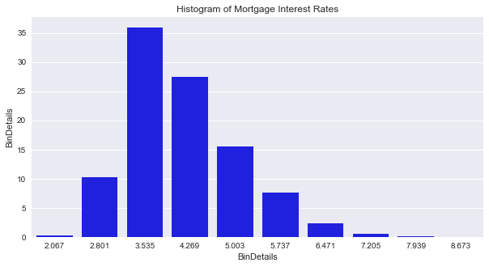

```python
ax = plt.figure(figsize = (10,5))
ax = sns.barplot(data = histDf, x = 'MidPoint', y = 'Percent', color = 'blue')
ax.set(title = 'Histogram of Mortgage Interest Rates');
```

### 6. dataShaping Action Set

a. Load and view the [dataShaping](https://go.documentation.sas.com/doc/en/pgmsascdc/v_017/casanpg/cas-datashaping-TblOfActions.htm?homeOnFail) action set. Notice that it contains two actions for transposing data, longToWide and wideToLong.

**Note:** The dataShaping action set was added in SAS Viya 2021.1.2. Prior versions should use the [transpose.transpose](https://go.documentation.sas.com/doc/en/pgmsascdc/v_018/caspg/cas-transpose-transpose.htm) action.

```python
conn.loadActionSet('dataShaping')
conn.dataShaping?
```

```
NOTE: Added action set 'dataShaping'.
```

```
Signature:   conn.dataShaping(*args, **kwargs)
Type:        Datashaping
String form: <swat.cas.actions.Datashaping object at 0x000001E024E74250>
File:        c:\programdata\anaconda3\lib\site-packages\swat\cas\actions.py
Docstring:
Data Shaping

Actions
-------
datashaping.longtowide : Reshapes a table containing thin records into a table
                         containing wide records.
datashaping.widetolong : Reshapes a table containing wide records into a table
                         containing thin records.
```

b. To work with the dataShaping action set, we will create a small five-row wide CAS table as a demonstration from the **customers_raw.csv** data source file.

```python
## Load the customers_raw.csv file into memory with the specified parameters
conn.loadTable(path = 'customers_raw.csv', caslib = 'PIVY',
               vars = ['ID','LoanCreditCard', 'SavingsAcct', 'CheckingAcct'],
               casOut = {'replace' : True})

## Reference the CAS table
customers = conn.CASTable('customers_raw', caslib = 'casuser')

## Create a five-row DataFrame from the wide table as a sample
df = (customers
      .sort_values('ID')
      .head())

## Upload the DataFrame to CAS
conn.upload(df,
            casOut = {'name' : 'wideTest',
                      'replace': True})

## Preview the new table
custTbl = conn.CASTable('wideTest', caslib = 'casuser')
custTbl.head()
```

```
NOTE: Cloud Analytic Services made the file customers_raw.csv available as table CUSTOMERS_RAW in caslib CASUSER(student).
NOTE: Cloud Analytic Services made the uploaded file available as table WIDETEST in caslib CASUSER(student).
NOTE: The table WIDETEST has been created in caslib CASUSER(student) from binary data uploaded to Cloud Analytic Services.
```

Selected Rows from Table WIDETEST

|  | ID | LoanCreditCard | SavingsAcct | CheckingAcct |
| --- | --- | --- | --- | --- |
| 0 | A-00000000000998843461 | 2.0 | 1.0 | 1.0 |
| 1 | A-00000000004223547876 | 1.0 | 1.0 | 1.0 |
| 2 | A-00000000023497268558 | 1.0 | 1.0 | 1.0 |
| 3 | A-00000000043949112296 | 3.0 | 1.0 | 1.0 |
| 4 | A-00000000055029522628 | 1.0 | 1.0 | 1.0 |

c. To transform the wide CAS table to a long table use the [dataShaping.wideToLong](https://go.documentation.sas.com/doc/en/pgmsascdc/v_018/casanpg/cas-datashaping-widetolong.htm) action. Start by creating two variables to specify the input CAS table and the output CAS table. Then in the wideToLong action, use

- the **inputTbl** variable to specify the input table
- the id parameter to specify the customer **ID** column
- the inputs parameter to specify the columns to transpose
- the variableName parameter to specify the name of the column in the output table that has values that are column names from the input table
- the valueName parameter to specify the name of a column in the output table that has values from the input table
- the casOut parameter to use the **outputTbl** variable to specify the new CAS table.

The action returns a **CASResults** object with information about the new CAS table.

```python
## Specify the input and output table information
inputTbl = {'name' : 'wideTest',
            'caslib' : 'casuser'}

outputTbl = dict(name = 'LongTest',
                 caslib = 'casuser',
                 replace = True)

## Tranpose the table
conn.wideToLong(table = inputTbl,
                id = 'ID',
                inputs = ['LoanCreditCard','SavingsAcct','CheckingAcct'],
                variableName = 'AccountType',
                valueName = 'AccountExists',
                casOut = outputTbl)
```

**§ OutputCasTables**

|  | casLib | Name | Rows | Columns | casTable |
| --- | --- | --- | --- | --- | --- |
| 0 | CASUSER(student) | LongTest | 15 | 4 | CASTable('LongTest', caslib='CASUSER(student)') |

elapsed 0.00481s · user 0.00258s · sys 0.00389s · mem 33.2MB

d. Preview the new CAS table. Notice that the wide table was transposed to a long table.

```python
longTbl = conn.CASTable('LongTest', caslib = 'casuser')
longTbl.head(15)
```

Selected Rows from Table LONGTEST

|  | ID | AccountType | AccountExists | _C0_ |
| --- | --- | --- | --- | --- |
| 0 | A-00000000004223547876 | LoanCreditCard | 1.0 | LoanCreditCard |
| 1 | A-00000000004223547876 | SavingsAcct | 1.0 | SavingsAcct |
| 2 | A-00000000004223547876 | CheckingAcct | 1.0 | CheckingAcct |
| 3 | A-00000000043949112296 | LoanCreditCard | 3.0 | LoanCreditCard |
| 4 | A-00000000043949112296 | SavingsAcct | 1.0 | SavingsAcct |
| 5 | A-00000000043949112296 | CheckingAcct | 1.0 | CheckingAcct |
| 6 | A-00000000023497268558 | LoanCreditCard | 1.0 | LoanCreditCard |
| 7 | A-00000000023497268558 | SavingsAcct | 1.0 | SavingsAcct |
| 8 | A-00000000023497268558 | CheckingAcct | 1.0 | CheckingAcct |
| 9 | A-00000000000998843461 | LoanCreditCard | 2.0 | LoanCreditCard |
| 10 | A-00000000000998843461 | SavingsAcct | 1.0 | SavingsAcct |
| 11 | A-00000000000998843461 | CheckingAcct | 1.0 | CheckingAcct |
| 12 | A-00000000055029522628 | LoanCreditCard | 1.0 | LoanCreditCard |
| 13 | A-00000000055029522628 | SavingsAcct | 1.0 | SavingsAcct |
| 14 | A-00000000055029522628 | CheckingAcct | 1.0 | CheckingAcct |

### 7. Terminate the CAS Session

It's best practice to always terminate the CAS session when you are done.

```python
conn.terminate()
```